# Completed_NLP_Project_Low_Code

## **Problem Statement**

### Business Context

In today's dynamic business landscape, organizations are increasingly recognizing the pivotal role customer feedback plays in shaping the trajectory of their products and services. The ability to swiftly and effectively respond to customer input not only fosters enhanced customer experiences but also serves as a catalyst for growth, prolonged customer engagement, and the nurturing of lifetime value relationships. As a dedicated Product Manager or Product Analyst, staying attuned to the voice of your customers is not just a best practice; it's a strategic imperative.

While your organization may be inundated with a wealth of customer-generated feedback and support tickets, your role entails much more than just processing these inputs. To make your efforts in managing customer experience and expectations truly impactful, you need a structured approach – a method that allows you to discern the most pressing issues, set priorities, and allocate resources judiciously. One of the most effective strategies at your disposal is to harness the power of Support Ticket Categorization.

### Objective

Develop an advanced support ticket categorization system that accurately classifies incoming tickets, assigns relevant tags based on their content, implements mechanisms and generate the first response based on the sentiment for prioritizing tickets for prompt resolution.

## **Sample of Expected Output**

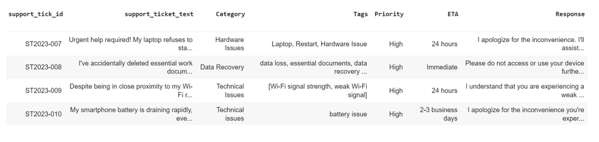

## **Please read the instructions carefully before starting the project.**

This is a commented Python Notebook file in which all the instructions and tasks to be performed are mentioned.

- Blanks '_______' are provided in the notebook that needs to be filled with an appropriate code to get the correct result. With every '_______' blank, there is a comment that briefly describes what needs to be filled in the blank space.
- Identify the task to be performed correctly, and only then proceed to write the required code.
- Please run the codes in a sequential manner from the beginning to avoid any unnecessary errors.
- Add the results/observations (wherever mentioned) derived from the analysis in the presentation and submit the same. Any mathematical or computational details which are a graded part of the project can be included in the Appendix section of the presentation.

## **Installing and Importing Necessary Libraries and Dependencies**

```python
# installation for GPU llama-cpp-python
# uncomment and run the following code in case GPU is being used

!CMAKE_ARGS="-DLLAMA_CUBLAS=on" FORCE_CMAKE=1 pip install llama-cpp-python==0.1.85 --force-reinstall --no-cache-dir -q  # Installs llama-cpp-python with specific CMake options, forcing reinstallation and ignoring the cache.
```

[output not shown]

```python
!nvidia-smi  # displays GPU status and usage details.
```

```
Mon Aug 12 14:38:43 2024
+---------------------------------------------------------------------------------------+
| NVIDIA-SMI 535.104.05             Driver Version: 535.104.05   CUDA Version: 12.2     |
|-----------------------------------------+----------------------+----------------------+
| GPU  Name                 Persistence-M | Bus-Id        Disp.A | Volatile Uncorr. ECC |
| Fan  Temp   Perf          Pwr:Usage/Cap |         Memory-Usage | GPU-Util  Compute M. |
|                                         |                      |               MIG M. |
|=========================================+======================+======================|
|   0  NVIDIA A100-SXM4-40GB          Off | 00000000:00:04.0 Off |                    0 |
| N/A   37C    P0              49W / 400W |    715MiB / 40960MiB |      0%      Default |
|                                         |                      |             Disabled |
+-----------------------------------------+----------------------+----------------------+

+---------------------------------------------------------------------------------------+
| Processes:                                                                            |
|  GPU   GI   CI        PID   Type   Process name                            GPU Memory |
|        ID   ID                                                             Usage      |
|=======================================================================================|
+---------------------------------------------------------------------------------------+
```

```python
# #installation for CPU llama-cpp-python
# #uncomment and run the following code in case GPU is not being used

# !CMAKE_ARGS="-DLLAMA_CUBLAS=off" FORCE_CMAKE=1 pip install llama-cpp-python==0.1.85 --force-reinstall --no-cache-dir -q
```

**Note** : There may be an error related to a dependency issue thrown by the pip package. This can be ignored as it will not impact the execution of the code.

```python
# # for downloading the models from HF Hub
# !pip install huggingface_hub==0.20.3 pandas==1.5.3 -q
```

```python
# !pip uninstall huggingface-hub pandas numpy -y  # uninstalls specified packages without asking for confirmation.
```

```python
!pip install huggingface-hub==0.23.2 pandas==2.1.4 numpy==1.23.0  # installs specific versions of the huggingface-hub, pandas, and numpy packages.
```

[output not shown]

```python
!pip install albumentations==1.4.12  # installs a specific version of albumentations for image augmentation.
!pip install tensorflow==2.17.0  # installs a specific version of TensorFlow for deep learning models.
```

```python
# function to download the model from the Hugging Face model hub
from huggingface_hub import hf_hub_download

# importing the Llama class from the llama_cpp module
from llama_cpp import Llama

# importing the json module
import json

# for loading and manipulating data
import pandas as pd

# for time computations
import time
```

## **Loading the Data**

```python
# from google.colab import drive
# drive.mount('/content/drive')
```

```python
# completed code to read the CSV file.
data = pd.read_csv("/content/Support_ticket_text_data_mid_term.csv")  # Loads data from a CSV file into a pandas DataFrame.
```

## **Data Overview**

### Checking the first 5 rows of the data

```python
# completed code to check the first 5 rows of the data
data.head()
```

|  | support_tick_id | support_ticket_text |
| --- | --- | --- |
| 0 | ST2023-006 | My internet connection has significantly slowe... |
| 1 | ST2023-007 | Urgent help required! My laptop refuses to sta... |
| 2 | ST2023-008 | I've accidentally deleted essential work docum... |
| 3 | ST2023-009 | Despite being in close proximity to my Wi-Fi r... |
| 4 | ST2023-010 | My smartphone battery is draining rapidly, eve... |

### Checking the shape of the data

```python
# completed code to check the shape of the data
data.shape
```

```
(21, 2)
```

### Checking the missing values in the data

```python
# completed code to check for missing values in the data
data.isna().sum()
```

|  | 0 |
| --- | --- |
| support_tick_id | 0 |
| support_ticket_text | 0 |

**dtype:** int64

## **Model Building**

### Loading the model

```python
model_name_or_path = "TheBloke/Mistral-7B-Instruct-v0.2-GGUF"  # Specifies the path or name of the model on Hugging Face.
model_basename = "mistral-7b-instruct-v0.2.Q6_K.gguf"  # Defines the base name of the model for easier reference.
```

```python
model_path = hf_hub_download(
    repo_id="TheBloke/Mistral-7B-Instruct-v0.2-GGUF", # Completed code to mention the repo_id
    filename="mistral-7b-instruct-v0.2.Q6_K.gguf"  # Completed code to mention the filename
)
```

```python
# uncomment and run the following code in case GPU is being used

llm = Llama(
    model_path=model_path,
    n_ctx=1024, # Context window
)
```

```
AVX = 1 | AVX2 = 1 | AVX512 = 0 | AVX512_VBMI = 0 | AVX512_VNNI = 0 | FMA = 1 | NEON = 0 | ARM_FMA = 0 | F16C = 1 | FP16_VA = 0 | WASM_SIMD = 0 | BLAS = 1 | SSE3 = 1 | SSSE3 = 1 | VSX = 0 |
```

```python
# uncomment and run the following code in case CPU is not being used

# llm = Llama(
#     model_path=model_path,
#     n_ctx=1024, # Context window
#     n_cores=-2 # Number of CPU cores to use
# )
```

### Utility functions

```python
def extract_json_data(json_str):
    if isinstance(json_str, dict):
        # Handle the case where json_str is already a dictionary
        return json_str
    else:
        # Proceed with original logic if json_str is a string
        try:
            # Find the indices of the opening and closing curly braces
            json_start = json_str.find('{')
            json_end = json_str.rfind('}')

            # Extract the JSON string
            json_string = json_str[json_start : json_end + 1]

            # Parse the JSON string into a Python dictionary
            json_data = json.loads(json_string)

            return json_data
        except:
            return {}
```

## **Task 1: Ticket Categorization and Returning Structured Output**

```python
# creating a copy of the data
data_1 = data.copy()
```

```python
#defining the response funciton for Task 1
def response_1(prompt, ticket):
    try:
        model_output = llm(
          f"""
          Q: {prompt}
          Support ticket: {ticket}
          A:
          """,
          max_tokens=256,  # Sets the maximum number of tokens for the model response.
          stop=["Q:", "\n"],  # Defines stopping conditions for the model's output generation.
          temperature=0.1,  # Sets the creativity of the model's responses.
          echo=False,  # Specifies not to echo the input in the model's output.
        )
        # Converts model output from JSON string to Python dictionary.
        response_json = json.loads(model_output["choices"][0]["text"])
        # Returns the content part of the model's output after splitting at ':'.
        return response_json["content"].split(":")[1]
    except json.JSONDecodeError:
        # Handles exceptions caused by JSON decoding errors.
        print(f"Warning: Unexpected response format for ticket: {ticket}")
        return {"error": "Invalid response format", "content": model_output["choices"][0]["text"]}
    except Exception as e:
        # Handles any other exceptions that occur.
        print(f"Error processing ticket: {e}")
        return {"error": "Processing failed", "message": str(e)}
```

```python
# stores the prompt string used to instruct the AI model on processing support tickets.
prompt_1 = """
Develop an advanced AI-driven support ticket response system that enhances customer service interactions by
Automatically categorizing incoming support tickets into predefined categories such as
    Network/Internet Connectivity Issues
    Account or Login Issues
    Billing Issues
    Software Bugs or Errors
    Other
Analyzing the sentiment of the ticket to gauge customer emotion and urgency.
Generating a tailored initial response that
    Acknowledges the customers specific issue.
    Offers preliminary advice or reassurance based on the issue’s category and detected sentiment.
    Reflects the urgency and specifics of the ticket, ensuring the response is empathetic and informative.

Instructions
 Read the provided support ticket text.
 Determine the most appropriate category for the ticket.
 Analyze the sentiment of the text to understand the customers emotional state.
 Generate a response that aligns with the category, sentiment, and details mentioned in the ticket.

The system should aim to provide quick, accurate, and empathetic responses that contribute to an effective and efficient customer service process. The output should clearly categorize the ticket, explain the choice of category, incorporate sentiment analysis, and tailor the response to the specifics of the ticket and its urgency.
"""
```

```python
# assuming response_1 is defined and accepts the given parameters correctly.
response = response_1(prompt_1, data_1['support_ticket_text'][0])

# assuming the response is a dictionary that contains a key 'Content'
if 'content' in response:
    print("Content:", response["content"].split(":")[1])
else:
    print("Content key not found in response.")
```

[output not shown]

```python
# check the first few rows of the DataFrame to ensure data is as expected
print(data_1.head())
```

```
  support_tick_id                                support_ticket_text
0      ST2023-006  My internet connection has significantly slowe...
1      ST2023-007  Urgent help required! My laptop refuses to sta...
2      ST2023-008  I've accidentally deleted essential work docum...
3      ST2023-009  Despite being in close proximity to my Wi-Fi r...
4      ST2023-010  My smartphone battery is draining rapidly, eve...
```

**Note**: The output of the model should be in a structured format (JSON format).

```python
start = time.time()  # captures the start time before processing begins.
data_1['model_response'] = data_1['support_ticket_text'].apply(lambda x: response_1(prompt_1, x))  # applies the response_1 function to each support ticket text and stores the results.
end = time.time()  # captures the end time after processing completes.
```

```
Llama.generate: prefix-match hit
```

```
Llama.generate: prefix-match hit
```

```
Llama.generate: prefix-match hit
```

```
Llama.generate: prefix-match hit
```

```
Llama.generate: prefix-match hit
```

```
Llama.generate: prefix-match hit
```

```
Llama.generate: prefix-match hit
```

```
Llama.generate: prefix-match hit
```

```
Llama.generate: prefix-match hit
```

```
Llama.generate: prefix-match hit
```

```
Llama.generate: prefix-match hit
```

```
Llama.generate: prefix-match hit
```

```
Llama.generate: prefix-match hit
```

```
Llama.generate: prefix-match hit
```

```
Llama.generate: prefix-match hit
```

```
Llama.generate: prefix-match hit
```

```
Llama.generate: prefix-match hit
```

```
Llama.generate: prefix-match hit
```

```
Llama.generate: prefix-match hit
```

```
Llama.generate: prefix-match hit
```

```
Llama.generate: prefix-match hit
```

```python
print("Time taken ",(end-start))  # prints the total time taken for processing.
```

```
Time taken  79.16023087501526
```

```python
# completed code to checking first five rows of the data to confirm whether the new column has been added
data_1.head()
```

|  | support_tick_id | support_ticket_text | model_response |
| --- | --- | --- | --- |
| 0 | ST2023-006 | My internet connection has significantly slowe... | {'error': 'Invalid response format', 'content'... |
| 1 | ST2023-007 | Urgent help required! My laptop refuses to sta... | {'error': 'Invalid response format', 'content'... |
| 2 | ST2023-008 | I've accidentally deleted essential work docum... | {'error': 'Invalid response format', 'content'... |
| 3 | ST2023-009 | Despite being in close proximity to my Wi-Fi r... | {'error': 'Invalid response format', 'content'... |
| 4 | ST2023-010 | My smartphone battery is draining rapidly, eve... | {'error': 'Invalid response format', 'content'... |

```python
i = 2  # sets the index value for the specific row.
print(data_1.loc[i, 'support_ticket_text'])  # Prints the support ticket text at the specified index.
```

```
I've accidentally deleted essential work documents, causing substantial data loss. I understand the need to avoid further actions on my device. Can you please prioritize the data recovery process and guide me through it?
```

```python
print(data_1.loc[i, 'model_response'])  # Prints the model's response for the support ticket at the specified index.
```

```
{'error': 'Invalid response format', 'content': ' Category: Data Loss or Recovery Issues'}
```

```python
# applies the function extract_json_data to parse the JSON data in 'model_response' and displays the first few entries of the parsed data.
data_1['model_response_parsed'] = data_1['model_response'].apply(extract_json_data)
data_1['model_response_parsed'].head()
```

|  | model_response_parsed |
| --- | --- |
| 0 | {'error': 'Invalid response format', 'content'... |
| 1 | {'error': 'Invalid response format', 'content'... |
| 2 | {'error': 'Invalid response format', 'content'... |
| 3 | {'error': 'Invalid response format', 'content'... |
| 4 | {'error': 'Invalid response format', 'content'... |

**dtype:** object

```python
data_1['model_response_parsed'].value_counts()
```

| model_response_parsed | count |
| --- | --- |
| {'error': 'Invalid response format', 'content': ' Category: Network/Internet Connectivity Issues'} | 5 |
| {'error': 'Invalid response format', 'content': ' Category: Hardware Issues'} | 3 |
| {'error': 'Invalid response format', 'content': ' Category: Software Bugs or Errors'} | 2 |
| {'error': 'Invalid response format', 'content': ' Category: Data Recovery Issues'} | 2 |
| {'error': 'Invalid response format', 'content': ' Category: Other (Hardware Issues)'} | 2 |
| {'error': 'Invalid response format', 'content': ' Category: Data Loss or Recovery Issues'} | 1 |
| {'error': 'Invalid response format', 'content': ' Category: Device Technical Issues (specifically related to hardware)'} | 1 |
| {'error': 'Invalid response format', 'content': ' Category: Account or Login Issues'} | 1 |
| {'error': 'Invalid response format', 'content': ' Category: Software Performance Issues'} | 1 |
| {'error': 'Invalid response format', 'content': ' Category: Software Bugs or Errors (Hardware issues can sometimes manifest as software bugs)'} | 1 |
| {'error': 'Invalid response format', 'content': ' Category: Display/Hardware Issues'} | 1 |
| {'error': 'Invalid response format', 'content': ' Category: Hardware Issues (specifically related to device malfunction)'} | 1 |

**dtype:** int64

```python
# normalizing the model_response_parsed column
model_response_parsed_df_1 = pd.json_normalize(data_1['model_response_parsed'])
model_response_parsed_df_1.head()
```

|  | error | content |
| --- | --- | --- |
| 0 | Invalid response format | Category: Network/Internet Connectivity Issues |
| 1 | Invalid response format | Category: Hardware Issues |
| 2 | Invalid response format | Category: Data Loss or Recovery Issues |
| 3 | Invalid response format | Category: Network/Internet Connectivity Issues |
| 4 | Invalid response format | Category: Device Technical Issues (specifical... |

```python
# concatinating two dataframes
data_with_parsed_model_output_1 = pd.concat([data_1, model_response_parsed_df_1], axis=1)
data_with_parsed_model_output_1.head()
```

|  | support_tick_id | support_ticket_text | model_response | model_response_parsed | error | content |
| --- | --- | --- | --- | --- | --- | --- |
| 0 | ST2023-006 | My internet connection has significantly slowe... | {'error': 'Invalid response format', 'content'... | {'error': 'Invalid response format', 'content'... | Invalid response format | Category: Network/Internet Connectivity Issues |
| 1 | ST2023-007 | Urgent help required! My laptop refuses to sta... | {'error': 'Invalid response format', 'content'... | {'error': 'Invalid response format', 'content'... | Invalid response format | Category: Hardware Issues |
| 2 | ST2023-008 | I've accidentally deleted essential work docum... | {'error': 'Invalid response format', 'content'... | {'error': 'Invalid response format', 'content'... | Invalid response format | Category: Data Loss or Recovery Issues |
| 3 | ST2023-009 | Despite being in close proximity to my Wi-Fi r... | {'error': 'Invalid response format', 'content'... | {'error': 'Invalid response format', 'content'... | Invalid response format | Category: Network/Internet Connectivity Issues |
| 4 | ST2023-010 | My smartphone battery is draining rapidly, eve... | {'error': 'Invalid response format', 'content'... | {'error': 'Invalid response format', 'content'... | Invalid response format | Category: Device Technical Issues (specifical... |

```python
# dropping model_response and model_response_parsed columns
final_data_1 = data_with_parsed_model_output_1.drop(['model_response','model_response_parsed'], axis=1)
final_data_1.head()
```

|  | support_tick_id | support_ticket_text | error | content |
| --- | --- | --- | --- | --- |
| 0 | ST2023-006 | My internet connection has significantly slowe... | Invalid response format | Category: Network/Internet Connectivity Issues |
| 1 | ST2023-007 | Urgent help required! My laptop refuses to sta... | Invalid response format | Category: Hardware Issues |
| 2 | ST2023-008 | I've accidentally deleted essential work docum... | Invalid response format | Category: Data Loss or Recovery Issues |
| 3 | ST2023-009 | Despite being in close proximity to my Wi-Fi r... | Invalid response format | Category: Network/Internet Connectivity Issues |
| 4 | ST2023-010 | My smartphone battery is draining rapidly, eve... | Invalid response format | Category: Device Technical Issues (specifical... |

## **Task 2: Creating Tags**

```python
# creating a copy of the data
data_2 = data.copy()
```

```python
def response_2(prompt,ticket,category):
    try:
        model_output = llm(
          f"""
          Q: {prompt}
          Support ticket: {ticket}
           Category: {category}
          A:
          """,
          max_tokens=256,
          stop=["Q:", "\n"],
          temperature=0.1,
          echo=False,
        )
        # Assuming the output should be JSON-formatted
        response_json = json.loads(model_output["choices"][0]["text"])
        return response_json
        # return response_json["content"].split(":")[1]
    except json.JSONDecodeError:
        print(f"Warning: Unexpected response format for ticket: {ticket}")
        return {"error": "Invalid response format", "content": model_output["choices"][0]["text"]}
    except Exception as e:
        print(f"Error processing ticket: {e}")
        return {"error": "Processing failed", "message": str(e)}
```

```python
prompt_2 = """
    Given a customer support ticket, analyze the content and generate relevant tags that summarize the issues or key themes present in the ticket.
    Consider aspects such as the type of technical issue, urgency, specific requests, or complaints made by the customer.
    """
```

**Note**: The output of the model should be in a structured format (JSON format).

```python
final_data_1['support_ticket_text'][0]
```

```
'My internet connection has significantly slowed down over the past two days, making it challenging to work efficiently from home. Frequent disconnections are causing major disruptions. Please assist in resolving this connectivity issue promptly.'
```

```python
final_data_1['content'][0]
```

```
' Category: Network/Internet Connectivity Issues'
```

```python
# assuming response_1 is defined and accepts the given parameters correctly.
response = response_2(prompt_2, final_data_1['support_ticket_text'][0],final_data_1['content'][0])

# assuming the response is a dictionary that contains a key 'Content'
if 'content' in response:
    print("Content:", response)
else:
    print("Content key not found in response.")
```

```
Llama.generate: prefix-match hit
```

```python
start = time.time()
data_2["model_response"]=final_data_1[['support_ticket_text','content']].apply(lambda x: response_2(prompt_2, x[0],x[1]),axis =1)
end = time.time()
```

```
Llama.generate: prefix-match hit
```

```
Llama.generate: prefix-match hit
```

```
Llama.generate: prefix-match hit
```

```
Llama.generate: prefix-match hit
```

```
Llama.generate: prefix-match hit
```

```
Llama.generate: prefix-match hit
```

```
Llama.generate: prefix-match hit
```

```
Llama.generate: prefix-match hit
```

```
Llama.generate: prefix-match hit
```

```
Llama.generate: prefix-match hit
```

```
Llama.generate: prefix-match hit
```

```
Llama.generate: prefix-match hit
```

```
Llama.generate: prefix-match hit
```

```
Llama.generate: prefix-match hit
```

```
Llama.generate: prefix-match hit
```

```
Llama.generate: prefix-match hit
```

```
Llama.generate: prefix-match hit
```

```
Llama.generate: prefix-match hit
```

```
Llama.generate: prefix-match hit
```

```
Llama.generate: prefix-match hit
```

```python
print("Time taken ",end-start)
```

```
Time taken  58.603764057159424
```

```python
# Write the code to check the first five rows of the data to confirm whether the new column has been added
data_2.head()
```

|  | support_tick_id | support_ticket_text | model_response |
| --- | --- | --- | --- |
| 0 | ST2023-006 | My internet connection has significantly slowe... | {'error': 'Invalid response format', 'content'... |
| 1 | ST2023-007 | Urgent help required! My laptop refuses to sta... | {'error': 'Invalid response format', 'content'... |
| 2 | ST2023-008 | I've accidentally deleted essential work docum... | {'error': 'Invalid response format', 'content'... |
| 3 | ST2023-009 | Despite being in close proximity to my Wi-Fi r... | {'error': 'Invalid response format', 'content'... |
| 4 | ST2023-010 | My smartphone battery is draining rapidly, eve... | {'error': 'Invalid response format', 'content'... |

```python
i = 2
print(data_2.loc[i, 'support_ticket_text'])
```

```
I've accidentally deleted essential work documents, causing substantial data loss. I understand the need to avoid further actions on my device. Can you please prioritize the data recovery process and guide me through it?
```

```python
print(data_2.loc[i, 'model_response'])
```

```
{'error': 'Invalid response format', 'content': '1. Data Loss'}
```

```python
# applying the function to the model response
data_2['model_response_parsed'] = data_2['model_response'].apply(extract_json_data)
```

```python
data_2["model_response_parsed"]
```

|  | model_response_parsed |
| --- | --- |
| 0 | {'error': 'Invalid response format', 'content'... |
| 1 | {'error': 'Invalid response format', 'content'... |
| 2 | {'error': 'Invalid response format', 'content'... |
| 3 | {'error': 'Invalid response format', 'content'... |
| 4 | {'error': 'Invalid response format', 'content'... |
| 5 | {'error': 'Invalid response format', 'content'... |
| 6 | {'error': 'Invalid response format', 'content'... |
| 7 | {'error': 'Invalid response format', 'content'... |
| 8 | {'error': 'Invalid response format', 'content'... |
| 9 | {'error': 'Invalid response format', 'content'... |
| 10 | {'error': 'Invalid response format', 'content'... |
| 11 | {'error': 'Invalid response format', 'content'... |
| 12 | {'error': 'Invalid response format', 'content'... |
| 13 | {'error': 'Invalid response format', 'content'... |
| 14 | {'error': 'Invalid response format', 'content'... |
| 15 | {'error': 'Invalid response format', 'content'... |
| 16 | {'error': 'Invalid response format', 'content'... |
| 17 | {'error': 'Invalid response format', 'content'... |
| 18 | {'error': 'Invalid response format', 'content'... |
| 19 | {'error': 'Invalid response format', 'content'... |
| 20 | {'error': 'Invalid response format', 'content'... |

**dtype:** object

```python
# normalizing the model_response_parsed column
model_response_parsed_df_2 = pd.json_normalize(data_2['model_response_parsed'])
model_response_parsed_df_2.head()
```

|  | error | content |
| --- | --- | --- |
| 0 | Invalid response format | 1. Internet Connection |
| 1 | Invalid response format | 1. Urgent |
| 2 | Invalid response format | 1. Data Loss |
| 3 | Invalid response format | 1. Network connectivity issues |
| 4 | Invalid response format | 1. Device Technical Issues |

```python
# concatinating two dataframes
data_with_parsed_model_output_2 = pd.concat([data_2, model_response_parsed_df_2], axis=1)
data_with_parsed_model_output_2.head()
```

|  | support_tick_id | support_ticket_text | model_response | model_response_parsed | error | content |
| --- | --- | --- | --- | --- | --- | --- |
| 0 | ST2023-006 | My internet connection has significantly slowe... | {'error': 'Invalid response format', 'content'... | {'error': 'Invalid response format', 'content'... | Invalid response format | 1. Internet Connection |
| 1 | ST2023-007 | Urgent help required! My laptop refuses to sta... | {'error': 'Invalid response format', 'content'... | {'error': 'Invalid response format', 'content'... | Invalid response format | 1. Urgent |
| 2 | ST2023-008 | I've accidentally deleted essential work docum... | {'error': 'Invalid response format', 'content'... | {'error': 'Invalid response format', 'content'... | Invalid response format | 1. Data Loss |
| 3 | ST2023-009 | Despite being in close proximity to my Wi-Fi r... | {'error': 'Invalid response format', 'content'... | {'error': 'Invalid response format', 'content'... | Invalid response format | 1. Network connectivity issues |
| 4 | ST2023-010 | My smartphone battery is draining rapidly, eve... | {'error': 'Invalid response format', 'content'... | {'error': 'Invalid response format', 'content'... | Invalid response format | 1. Device Technical Issues |

```python
# dropping model_response and model_response_parsed columns
final_data_2 = data_with_parsed_model_output_2.drop(['model_response','model_response_parsed'], axis=1)
final_data_2.head()
```

|  | support_tick_id | support_ticket_text | error | content |
| --- | --- | --- | --- | --- |
| 0 | ST2023-006 | My internet connection has significantly slowe... | Invalid response format | 1. Internet Connection |
| 1 | ST2023-007 | Urgent help required! My laptop refuses to sta... | Invalid response format | 1. Urgent |
| 2 | ST2023-008 | I've accidentally deleted essential work docum... | Invalid response format | 1. Data Loss |
| 3 | ST2023-009 | Despite being in close proximity to my Wi-Fi r... | Invalid response format | 1. Network connectivity issues |
| 4 | ST2023-010 | My smartphone battery is draining rapidly, eve... | Invalid response format | 1. Device Technical Issues |

```python
final_data_2 = final_data_2.rename(columns={"content":"Tags"})
```

```python
# checking the value counts of Category column
final_data_2['Tags'].value_counts()
```

| Tags | count |
| --- | --- |
| 1. Data Loss | 2 |
| 1. Hardware Issues | 2 |
| 1. Hardware issues | 2 |
| 1. Internet Connection | 1 |
| 1. Display Issues | 1 |
| Tags: Internet connection, Slow speed, Frequent disconnections, Productivity loss, Urgent, Job-related, Diagnosis, Resolution. | 1 |
| 1. Data Recovery Issues | 1 |
| 1. Network/Internet Connectivity Issues | 1 |
| 1. Network issues | 1 |
| 1. Hardware Problems | 1 |
| 1. Graphics Card Malfunction | 1 |
| 1. Urgent | 1 |
| 1. External Hard Drive | 1 |
| 1. Software Performance Issues | 1 |
| 1. Account Issues | 1 |
| 1. Device Technical Issues | 1 |
| 1. Network connectivity issues | 1 |
| 1. Software Compatibility Issues | 1 |

**dtype:** int64

```python
final_data_2 = pd.concat([final_data_2,final_data_1["content"]],axis=1)
```

```python
final_data_2 = final_data_2[["support_tick_id","support_ticket_text","Tags","content"]]
final_data_2
```

|  | support_tick_id | support_ticket_text | Tags | content |
| --- | --- | --- | --- | --- |
| 0 | ST2023-006 | My internet connection has significantly slowe... | 1. Internet Connection | Category: Network/Internet Connectivity Issues |
| 1 | ST2023-007 | Urgent help required! My laptop refuses to sta... | 1. Urgent | Category: Hardware Issues |
| 2 | ST2023-008 | I've accidentally deleted essential work docum... | 1. Data Loss | Category: Data Loss or Recovery Issues |
| 3 | ST2023-009 | Despite being in close proximity to my Wi-Fi r... | 1. Network connectivity issues | Category: Network/Internet Connectivity Issues |
| 4 | ST2023-010 | My smartphone battery is draining rapidly, eve... | 1. Device Technical Issues | Category: Device Technical Issues (specifical... |
| 5 | ST2023-011 | I'm locked out of my online banking account an... | 1. Account Issues | Category: Account or Login Issues |
| 6 | ST2023-012 | My computer's performance is sluggish, severel... | 1. Software Performance Issues | Category: Software Performance Issues |
| 7 | ST2023-013 | I'm experiencing a recurring blue screen error... | 1. Hardware Issues | Category: Software Bugs or Errors |
| 8 | ST2023-014 | My external hard drive isn't being recognized ... | 1. External Hard Drive | Category: Hardware Issues |
| 9 | ST2023-015 | The graphics card in my gaming laptop seems to... | 1. Graphics Card Malfunction | Category: Software Bugs or Errors (Hardware i... |
| 10 | ST2023-016 | I accidentally formatted my USB drive with cri... | 1. Data Loss | Category: Data Recovery Issues |
| 11 | ST2023-017 | My computer's screen has gone black, and I can... | 1. Display Issues | Category: Display/Hardware Issues |
| 12 | ST2023-018 | I accidentally spilled water on my laptop, and... | 1. Hardware Issues | Category: Hardware Issues (specifically relat... |
| 13 | ST2023-019 | My USB flash drive is physically damaged, and ... | 1. Hardware issues | Category: Other (Hardware Issues) |
| 14 | ST2023-020 | The touchpad on my laptop has stopped working,... | 1. Hardware Problems | Category: Hardware Issues |
| 15 | ST2023-021 | My internet connection is frequently dropping,... | 1. Network issues | Category: Network/Internet Connectivity Issues |
| 16 | ST2023-022 | Wi-Fi is inconsistent despite proximity to the... | 1. Network/Internet Connectivity Issues | Category: Network/Internet Connectivity Issues |
| 17 | ST2023-023 | I accidentally formatted my USB drive with cru... | 1. Data Recovery Issues | Category: Data Recovery Issues |
| 18 | ST2023-024 | My external hard drive isn't being recognized,... | 1. Hardware issues | Category: Other (Hardware Issues) |
| 19 | ST2023-025 | I am experiencing a critical problem with my i... | Tags: Internet connection, Slow speed, Freque... | Category: Network/Internet Connectivity Issues |
| 20 | ST2023-026 | I hope this message finds you well. I am writi... | 1. Software Compatibility Issues | Category: Software Bugs or Errors |

```python
final_data_2.columns
```

```
Index(['support_tick_id', 'support_ticket_text', 'Tags', 'content'], dtype='object')
```

```python
final_data_2 = final_data_2.rename(columns={"content":"Category" })
```

```python
final_data_2.columns
```

```
Index(['support_tick_id', 'support_ticket_text', 'Tags', 'Category'], dtype='object')
```

## **Task 3: Assigning Priority and ETA**

```python
# creating a copy of the data
data_3 = data.copy()
```

```python
def response_3(prompt,ticket,category,tags):
    try:
        model_output = llm(
          f"""
          Q: {prompt}
          Support ticket: {ticket}
           Category: {category}
           Tags: {tags}
          A:
          """,
          max_tokens=256,
          stop=["Q:", "\n"],
          temperature=0.5,
          echo=False,
        )
        # Assuming the output should be JSON-formatted
        response_json = json.loads(model_output["choices"][0]["text"])
        return response_json
        # return response_json["content"].split(":")[1]
    except json.JSONDecodeError:
        print(f"Warning: Unexpected response format for ticket: {ticket}")
        return {"error": "Invalid response format", "content": model_output["choices"][0]["text"]}
    except Exception as e:
        print(f"Error processing ticket: {e}")
        return {"error": "Processing failed", "message": str(e)}
```

```python
prompt_3 = """
Review the details of a customer support ticket, including its category and associated tags.
1. Determine the appropriate priority level for the ticket based on the urgency of the issue, its impact on the user, and the complexity as indicated by the category and tags. Choose from the following options: Low, Medium, High, Urgent.
2. Assign an ETA for resolving the issue based on the determined priority level with the following mappings:
   - Urgent = 1hr
   - High = 4hrs
   - Medium = 6hrs
   - Low = 24hrs
3. Format your response as a statement in the format: 'Priority Level = [priority level]|ETA = [ETA]', replacing [priority level] and [ETA] with the appropriate values for each ticket.
"""
```

**Note**: The output of the model should be in a structured format (JSON format).

```python
# applying generate_llama_response function on support_ticket_text column
start = time.time()
data_3['model_response'] = final_data_2[['support_ticket_text','Category','Tags']].apply(lambda x: response_3(prompt_3, x[0],x[1],x[2]),axis=1)
end = time.time()
```

```
Llama.generate: prefix-match hit
```

```
Llama.generate: prefix-match hit
```

```
Llama.generate: prefix-match hit
```

```
Llama.generate: prefix-match hit
```

```
Llama.generate: prefix-match hit
```

```
Llama.generate: prefix-match hit
```

```
Llama.generate: prefix-match hit
```

```
Llama.generate: prefix-match hit
```

```
Llama.generate: prefix-match hit
```

```
Llama.generate: prefix-match hit
```

```
Llama.generate: prefix-match hit
```

```
Llama.generate: prefix-match hit
```

```
Llama.generate: prefix-match hit
```

```
Llama.generate: prefix-match hit
```

```
Llama.generate: prefix-match hit
```

```
Llama.generate: prefix-match hit
```

```
Llama.generate: prefix-match hit
```

```
Llama.generate: prefix-match hit
```

```
Llama.generate: prefix-match hit
```

```
Llama.generate: prefix-match hit
```

```python
print("Time taken ",(end-start))
```

```
Time taken  100.88090467453003
```

```python
# write the code to check the first five rows of the data to confirm whether the new column has been added
data_3.head()
```

|  | support_tick_id | support_ticket_text | model_response |
| --- | --- | --- | --- |
| 0 | ST2023-006 | My internet connection has significantly slowe... | {'error': 'Invalid response format', 'content'... |
| 1 | ST2023-007 | Urgent help required! My laptop refuses to sta... | {'error': 'Invalid response format', 'content'... |
| 2 | ST2023-008 | I've accidentally deleted essential work docum... | {'error': 'Invalid response format', 'content'... |
| 3 | ST2023-009 | Despite being in close proximity to my Wi-Fi r... | {'error': 'Invalid response format', 'content'... |
| 4 | ST2023-010 | My smartphone battery is draining rapidly, eve... | {'error': 'Invalid response format', 'content'... |

```python
i = 2
print(data_3.loc[i, 'support_ticket_text'])
```

```
I've accidentally deleted essential work documents, causing substantial data loss. I understand the need to avoid further actions on my device. Can you please prioritize the data recovery process and guide me through it?
```

```python
print(data_3.loc[i, 'model_response'])
```

```
{'error': 'Invalid response format', 'content': ' Priority Level = High|ETA = 4hrs'}
```

```python
# applying the function to the model response
data_3['model_response_parsed'] = data_3['model_response'].apply(extract_json_data)
data_3['model_response_parsed'].head()
```

|  | model_response_parsed |
| --- | --- |
| 0 | {'error': 'Invalid response format', 'content'... |
| 1 | {'error': 'Invalid response format', 'content'... |
| 2 | {'error': 'Invalid response format', 'content'... |
| 3 | {'error': 'Invalid response format', 'content'... |
| 4 | {'error': 'Invalid response format', 'content'... |

**dtype:** object

```python
# normalizing the model_response_parsed column
model_response_parsed_df_3 = pd.json_normalize(data_3['model_response_parsed'])
model_response_parsed_df_3.head(21)
```

|  | error | content |
| --- | --- | --- |
| 0 | Invalid response format | Priority Level = High\|ETA = 4hrs |
| 1 | Invalid response format | Priority Level = Urgent \| ETA = 1hr |
| 2 | Invalid response format | Priority Level = High\|ETA = 4hrs |
| 3 | Invalid response format | Priority Level = Medium\|ETA = 6hrs |
| 4 | Invalid response format | Priority Level = High\|ETA = 4hrs |
| 5 | Invalid response format | Priority Level = Urgent\|ETA = 1hr |
| 6 | Invalid response format | Priority Level = High\|ETA = 4hrs |
| 7 | Invalid response format | Priority Level = High\|ETA = 4hrs |
| 8 | Invalid response format | Priority Level = High \| ETA = 4hrs |
| 9 | Invalid response format | Priority Level = High\|ETA = 4hrs |
| 10 | Invalid response format | Priority Level = High\|ETA = 4hrs |
| 11 | Invalid response format | Priority Level = Urgent\|ETA = 1hr |
| 12 | Invalid response format | Priority Level = High \| ETA = 4hrs |
| 13 | Invalid response format | Priority Level = Urgent \| ETA = 1hr |
| 14 | Invalid response format | Priority Level = High\|ETA = 4hrs |
| 15 | Invalid response format | Priority Level = Urgent\|ETA = 1hr |
| 16 | Invalid response format | Priority Level = High\|ETA = 4hrs |
| 17 | Invalid response format | Priority Level = High\|ETA = 4hrs |
| 18 | Invalid response format | Priority Level = High\|ETA = 4hrs |
| 19 | Invalid response format | Priority Level = Urgent\|ETA = 1hr. |
| 20 | Invalid response format | Priority Level = High\|ETA = 4hrs. This issue ... |

```python
import pandas as pd

# assuming data_3 is your existing DataFrame loaded with the data
# and assuming the relevant data is in the 'model_response_parsed' column

# extract the 'content' field from the 'model_response_parsed' dictionaries
data_3['content'] = data_3['model_response_parsed'].apply(lambda x: x.get('content', '') if isinstance(x, dict) else '')

# splitting the 'content' column into two separate columns 'Priority Level' and 'ETA'
data_3[['Priority Level', 'ETA']] = data_3['content'].str.split('|', expand=True)

# removing any unnecessary text from these new columns to clean up the data
data_3['Priority Level'] = data_3['Priority Level'].str.replace('Priority Level = ', '').str.strip()
data_3['ETA'] = data_3['ETA'].str.replace('ETA = ', '').str.strip()

# now, data_3 should have two separate columns for 'Priority Level' and 'ETA' with the correct values
print(data_3[['Priority Level', 'ETA']])
```

```
   Priority Level                                                ETA
0            High                                               4hrs
1          Urgent                                                1hr
2            High                                               4hrs
3          Medium                                               6hrs
4            High                                               4hrs
5          Urgent                                                1hr
6            High                                               4hrs
7            High                                               4hrs
8            High                                               4hrs
9            High                                               4hrs
10           High                                               4hrs
11         Urgent                                                1hr
12           High                                               4hrs
13         Urgent                                                1hr
14           High                                               4hrs
15         Urgent                                                1hr
16           High                                               4hrs
17           High                                               4hrs
18           High                                               4hrs
19         Urgent                                               1hr.
20           High  4hrs. This issue is categorized as a software ...
```

```python
# concatinating two dataframes
data_with_parsed_model_output_3 = pd.concat([data_3, model_response_parsed_df_3], axis=1)
data_with_parsed_model_output_3.head()
```

|  | support_tick_id | support_ticket_text | model_response | model_response_parsed | content | Priority Level | ETA | error | content |
| --- | --- | --- | --- | --- | --- | --- | --- | --- | --- |
| 0 | ST2023-006 | My internet connection has significantly slowe... | {'error': 'Invalid response format', 'content'... | {'error': 'Invalid response format', 'content'... | Priority Level = High\|ETA = 4hrs | High | 4hrs | Invalid response format | Priority Level = High\|ETA = 4hrs |
| 1 | ST2023-007 | Urgent help required! My laptop refuses to sta... | {'error': 'Invalid response format', 'content'... | {'error': 'Invalid response format', 'content'... | Priority Level = Urgent \| ETA = 1hr | Urgent | 1hr | Invalid response format | Priority Level = Urgent \| ETA = 1hr |
| 2 | ST2023-008 | I've accidentally deleted essential work docum... | {'error': 'Invalid response format', 'content'... | {'error': 'Invalid response format', 'content'... | Priority Level = High\|ETA = 4hrs | High | 4hrs | Invalid response format | Priority Level = High\|ETA = 4hrs |
| 3 | ST2023-009 | Despite being in close proximity to my Wi-Fi r... | {'error': 'Invalid response format', 'content'... | {'error': 'Invalid response format', 'content'... | Priority Level = Medium\|ETA = 6hrs | Medium | 6hrs | Invalid response format | Priority Level = Medium\|ETA = 6hrs |
| 4 | ST2023-010 | My smartphone battery is draining rapidly, eve... | {'error': 'Invalid response format', 'content'... | {'error': 'Invalid response format', 'content'... | Priority Level = High\|ETA = 4hrs | High | 4hrs | Invalid response format | Priority Level = High\|ETA = 4hrs |

```python
# dropping model_response and model_response_parsed columns
final_data_3 = data_with_parsed_model_output_3.drop(['model_response','model_response_parsed'], axis=1)
final_data_3.head()
```

|  | support_tick_id | support_ticket_text | content | Priority Level | ETA | error | content |
| --- | --- | --- | --- | --- | --- | --- | --- |
| 0 | ST2023-006 | My internet connection has significantly slowe... | Priority Level = High\|ETA = 4hrs | High | 4hrs | Invalid response format | Priority Level = High\|ETA = 4hrs |
| 1 | ST2023-007 | Urgent help required! My laptop refuses to sta... | Priority Level = Urgent \| ETA = 1hr | Urgent | 1hr | Invalid response format | Priority Level = Urgent \| ETA = 1hr |
| 2 | ST2023-008 | I've accidentally deleted essential work docum... | Priority Level = High\|ETA = 4hrs | High | 4hrs | Invalid response format | Priority Level = High\|ETA = 4hrs |
| 3 | ST2023-009 | Despite being in close proximity to my Wi-Fi r... | Priority Level = Medium\|ETA = 6hrs | Medium | 6hrs | Invalid response format | Priority Level = Medium\|ETA = 6hrs |
| 4 | ST2023-010 | My smartphone battery is draining rapidly, eve... | Priority Level = High\|ETA = 4hrs | High | 4hrs | Invalid response format | Priority Level = High\|ETA = 4hrs |

```python
final_data_3 = pd.concat([final_data_3,final_data_2[["Category","Tags"]]],axis=1)
```

```python
final_data_3.columns
```

```
Index(['support_tick_id', 'support_ticket_text', 'content', 'Priority Level',
       'ETA', 'error', 'content', 'Category', 'Tags'],
      dtype='object')
```

```python
final_data_3.rename(columns={"content":"Priority"},inplace=True)
```

```python
final_data_3.loc[0,"Priority"] #lambda x: x.split("|")[1]
```

|  | 0 |
| --- | --- |
| Priority | Priority Level = High\|ETA = 4hrs |
| Priority | Priority Level = High\|ETA = 4hrs |

**dtype:** object

```python
# dropping the 'content' column from the DataFrame
final_data_3.drop('Priority', axis=1, inplace=True)
```

```python
final_data_3
```

|  | support_tick_id | support_ticket_text | Priority Level | ETA | error | Category | Tags |
| --- | --- | --- | --- | --- | --- | --- | --- |
| 0 | ST2023-006 | My internet connection has significantly slowe... | High | 4hrs | Invalid response format | Category: Network/Internet Connectivity Issues | 1. Internet Connection |
| 1 | ST2023-007 | Urgent help required! My laptop refuses to sta... | Urgent | 1hr | Invalid response format | Category: Hardware Issues | 1. Urgent |
| 2 | ST2023-008 | I've accidentally deleted essential work docum... | High | 4hrs | Invalid response format | Category: Data Loss or Recovery Issues | 1. Data Loss |
| 3 | ST2023-009 | Despite being in close proximity to my Wi-Fi r... | Medium | 6hrs | Invalid response format | Category: Network/Internet Connectivity Issues | 1. Network connectivity issues |
| 4 | ST2023-010 | My smartphone battery is draining rapidly, eve... | High | 4hrs | Invalid response format | Category: Device Technical Issues (specifical... | 1. Device Technical Issues |
| 5 | ST2023-011 | I'm locked out of my online banking account an... | Urgent | 1hr | Invalid response format | Category: Account or Login Issues | 1. Account Issues |
| 6 | ST2023-012 | My computer's performance is sluggish, severel... | High | 4hrs | Invalid response format | Category: Software Performance Issues | 1. Software Performance Issues |
| 7 | ST2023-013 | I'm experiencing a recurring blue screen error... | High | 4hrs | Invalid response format | Category: Software Bugs or Errors | 1. Hardware Issues |
| 8 | ST2023-014 | My external hard drive isn't being recognized ... | High | 4hrs | Invalid response format | Category: Hardware Issues | 1. External Hard Drive |
| 9 | ST2023-015 | The graphics card in my gaming laptop seems to... | High | 4hrs | Invalid response format | Category: Software Bugs or Errors (Hardware i... | 1. Graphics Card Malfunction |
| 10 | ST2023-016 | I accidentally formatted my USB drive with cri... | High | 4hrs | Invalid response format | Category: Data Recovery Issues | 1. Data Loss |
| 11 | ST2023-017 | My computer's screen has gone black, and I can... | Urgent | 1hr | Invalid response format | Category: Display/Hardware Issues | 1. Display Issues |
| 12 | ST2023-018 | I accidentally spilled water on my laptop, and... | High | 4hrs | Invalid response format | Category: Hardware Issues (specifically relat... | 1. Hardware Issues |
| 13 | ST2023-019 | My USB flash drive is physically damaged, and ... | Urgent | 1hr | Invalid response format | Category: Other (Hardware Issues) | 1. Hardware issues |
| 14 | ST2023-020 | The touchpad on my laptop has stopped working,... | High | 4hrs | Invalid response format | Category: Hardware Issues | 1. Hardware Problems |
| 15 | ST2023-021 | My internet connection is frequently dropping,... | Urgent | 1hr | Invalid response format | Category: Network/Internet Connectivity Issues | 1. Network issues |
| 16 | ST2023-022 | Wi-Fi is inconsistent despite proximity to the... | High | 4hrs | Invalid response format | Category: Network/Internet Connectivity Issues | 1. Network/Internet Connectivity Issues |
| 17 | ST2023-023 | I accidentally formatted my USB drive with cru... | High | 4hrs | Invalid response format | Category: Data Recovery Issues | 1. Data Recovery Issues |
| 18 | ST2023-024 | My external hard drive isn't being recognized,... | High | 4hrs | Invalid response format | Category: Other (Hardware Issues) | 1. Hardware issues |
| 19 | ST2023-025 | I am experiencing a critical problem with my i... | Urgent | 1hr. | Invalid response format | Category: Network/Internet Connectivity Issues | Tags: Internet connection, Slow speed, Freque... |
| 20 | ST2023-026 | I hope this message finds you well. I am writi... | High | 4hrs. This issue is categorized as a software ... | Invalid response format | Category: Software Bugs or Errors | 1. Software Compatibility Issues |

```python
final_data_3 = final_data_3[["support_tick_id","support_ticket_text","Category","Priority Level","Tags","ETA"]]
```

```python
final_data_3
```

|  | support_tick_id | support_ticket_text | Category | Priority Level | Tags | ETA |
| --- | --- | --- | --- | --- | --- | --- |
| 0 | ST2023-006 | My internet connection has significantly slowe... | Category: Network/Internet Connectivity Issues | High | 1. Internet Connection | 4hrs |
| 1 | ST2023-007 | Urgent help required! My laptop refuses to sta... | Category: Hardware Issues | Urgent | 1. Urgent | 1hr |
| 2 | ST2023-008 | I've accidentally deleted essential work docum... | Category: Data Loss or Recovery Issues | High | 1. Data Loss | 4hrs |
| 3 | ST2023-009 | Despite being in close proximity to my Wi-Fi r... | Category: Network/Internet Connectivity Issues | Medium | 1. Network connectivity issues | 6hrs |
| 4 | ST2023-010 | My smartphone battery is draining rapidly, eve... | Category: Device Technical Issues (specifical... | High | 1. Device Technical Issues | 4hrs |
| 5 | ST2023-011 | I'm locked out of my online banking account an... | Category: Account or Login Issues | Urgent | 1. Account Issues | 1hr |
| 6 | ST2023-012 | My computer's performance is sluggish, severel... | Category: Software Performance Issues | High | 1. Software Performance Issues | 4hrs |
| 7 | ST2023-013 | I'm experiencing a recurring blue screen error... | Category: Software Bugs or Errors | High | 1. Hardware Issues | 4hrs |
| 8 | ST2023-014 | My external hard drive isn't being recognized ... | Category: Hardware Issues | High | 1. External Hard Drive | 4hrs |
| 9 | ST2023-015 | The graphics card in my gaming laptop seems to... | Category: Software Bugs or Errors (Hardware i... | High | 1. Graphics Card Malfunction | 4hrs |
| 10 | ST2023-016 | I accidentally formatted my USB drive with cri... | Category: Data Recovery Issues | High | 1. Data Loss | 4hrs |
| 11 | ST2023-017 | My computer's screen has gone black, and I can... | Category: Display/Hardware Issues | Urgent | 1. Display Issues | 1hr |
| 12 | ST2023-018 | I accidentally spilled water on my laptop, and... | Category: Hardware Issues (specifically relat... | High | 1. Hardware Issues | 4hrs |
| 13 | ST2023-019 | My USB flash drive is physically damaged, and ... | Category: Other (Hardware Issues) | Urgent | 1. Hardware issues | 1hr |
| 14 | ST2023-020 | The touchpad on my laptop has stopped working,... | Category: Hardware Issues | High | 1. Hardware Problems | 4hrs |
| 15 | ST2023-021 | My internet connection is frequently dropping,... | Category: Network/Internet Connectivity Issues | Urgent | 1. Network issues | 1hr |
| 16 | ST2023-022 | Wi-Fi is inconsistent despite proximity to the... | Category: Network/Internet Connectivity Issues | High | 1. Network/Internet Connectivity Issues | 4hrs |
| 17 | ST2023-023 | I accidentally formatted my USB drive with cru... | Category: Data Recovery Issues | High | 1. Data Recovery Issues | 4hrs |
| 18 | ST2023-024 | My external hard drive isn't being recognized,... | Category: Other (Hardware Issues) | High | 1. Hardware issues | 4hrs |
| 19 | ST2023-025 | I am experiencing a critical problem with my i... | Category: Network/Internet Connectivity Issues | Urgent | Tags: Internet connection, Slow speed, Freque... | 1hr. |
| 20 | ST2023-026 | I hope this message finds you well. I am writi... | Category: Software Bugs or Errors | High | 1. Software Compatibility Issues | 4hrs. This issue is categorized as a software ... |

```python
# applying generate_llama_response function on support_ticket_text column
start = time.time()
data_3['model_response'] = final_data_2[['support_ticket_text','Category','Tags']].apply(lambda x: response_3(prompt_3, x[0],x[1],x[2]),axis=1)
end = time.time()
```

```
Llama.generate: prefix-match hit
```

```
Llama.generate: prefix-match hit
```

```
Llama.generate: prefix-match hit
```

```
Llama.generate: prefix-match hit
```

```
Llama.generate: prefix-match hit
```

```
Llama.generate: prefix-match hit
```

```
Llama.generate: prefix-match hit
```

```
Llama.generate: prefix-match hit
```

```
Llama.generate: prefix-match hit
```

```
Llama.generate: prefix-match hit
```

```
Llama.generate: prefix-match hit
```

```
Llama.generate: prefix-match hit
```

```
Llama.generate: prefix-match hit
```

```
Llama.generate: prefix-match hit
```

```
Llama.generate: prefix-match hit
```

```
Llama.generate: prefix-match hit
```

```
Llama.generate: prefix-match hit
```

```
Llama.generate: prefix-match hit
```

```
Llama.generate: prefix-match hit
```

```
Llama.generate: prefix-match hit
```

```python
data_3.head()
```

|  | support_tick_id | support_ticket_text | model_response | model_response_parsed | content | Priority Level | ETA |
| --- | --- | --- | --- | --- | --- | --- | --- |
| 0 | ST2023-006 | My internet connection has significantly slowe... | {'error': 'Invalid response format', 'content'... | {'error': 'Invalid response format', 'content'... | Priority Level = High\|ETA = 4hrs | High | 4hrs |
| 1 | ST2023-007 | Urgent help required! My laptop refuses to sta... | {'error': 'Invalid response format', 'content'... | {'error': 'Invalid response format', 'content'... | Priority Level = Urgent \| ETA = 1hr | Urgent | 1hr |
| 2 | ST2023-008 | I've accidentally deleted essential work docum... | {'error': 'Invalid response format', 'content'... | {'error': 'Invalid response format', 'content'... | Priority Level = High\|ETA = 4hrs | High | 4hrs |
| 3 | ST2023-009 | Despite being in close proximity to my Wi-Fi r... | {'error': 'Invalid response format', 'content'... | {'error': 'Invalid response format', 'content'... | Priority Level = Medium\|ETA = 6hrs | Medium | 6hrs |
| 4 | ST2023-010 | My smartphone battery is draining rapidly, eve... | {'error': 'Invalid response format', 'content'... | {'error': 'Invalid response format', 'content'... | Priority Level = High\|ETA = 4hrs | High | 4hrs |

```python
i = 2
print(data_3.loc[i, 'support_ticket_text'])
```

```
I've accidentally deleted essential work documents, causing substantial data loss. I understand the need to avoid further actions on my device. Can you please prioritize the data recovery process and guide me through it?
```

```python
print(data_3.loc[i, 'model_response'])
```

```
{'error': 'Invalid response format', 'content': ' Priority Level = High|ETA = 4hrs'}
```

## **Task 4 - Creating a Draft Response**

```python
# creating a copy of the data
data_4 = data.copy()
```

```python
def response_4(prompt,ticket,category,tags,priority, ETA):
    model_output = llm(
      f"""
      Q: {prompt}
      Support ticket: {ticket}
      Category : {category}
      Tags : {tags}
      Priority: {priority}
      ETA: {ETA}
      A:
      """,
      max_tokens=256, #completed code to set the maximum number of tokens the model should generate for this task.
      stop=["Q:", "\n"],
      temperature=-.05, #completed code to set the value for temperature.
      echo=False,
    )

    temp_output = model_output["choices"][0]["text"]


    return temp_output
```

```python
prompt_4 = """
"For each support ticket, generate a response that includes a specific acknowledgment of the issue described, a statement reflecting the urgency level, a clear explanation of expected resolution time (ETA), and a closing reassurance. Ensure no component is omitted."
"""
```

**Note** : For this task, we will not be using the *`extract_json_data`* function. Hence, the output from the model should be a plain string and not a JSON object.

```python
#applying generate_llama_response function on support_ticket_text column
start = time.time()
data_4['model_response'] = final_data_3[['support_ticket_text','Category','Tags','Priority Level' , "ETA"]].apply(lambda x: response_4(prompt_4, x[0],x[1],x[2],x[3],x[4]),axis=1)
end = time.time()
```

```python
print("Time taken",(end-start))
```

```
Time taken 338.4855797290802
```

```python
# write the code to check the first five rows of the data to confirm whether the new column has been added
data_4.head(5)
```

|  | support_tick_id | support_ticket_text | model_response |
| --- | --- | --- | --- |
| 0 | ST2023-006 | My internet connection has significantly slowe... | Thank you for reporting the connectivity issue... |
| 1 | ST2023-007 | Urgent help required! My laptop refuses to sta... | subject: Urgent Issue with Your Laptop: Assur... |
| 2 | ST2023-008 | I've accidentally deleted essential work docum... | subject: Urgent Data Recovery Request |
| 3 | ST2023-009 | Despite being in close proximity to my Wi-Fi r... | Thank you for contacting us with regards to th... |
| 4 | ST2023-010 | My smartphone battery is draining rapidly, eve... | 1. Dear [Customer's Name], |

```python
data_4.loc[5,"model_response"]
```

```
" subject: Re: Urgent [#862197]: You've submitted an urgent Account/Login Issue Ticket, I hear you - and understand this requires priority! 🚀🧾"
```

```python
i = 2
print(data_4.loc[i, 'support_ticket_text'])
```

```
I've accidentally deleted essential work documents, causing substantial data loss. I understand the need to avoid further actions on my device. Can you please prioritize the data recovery process and guide me through it?
```

```python
print(data_4.loc[i, 'model_response'])
```

```
 subject: Urgent Data Recovery Request
```

```python
final_data_4 = pd.concat([final_data_3,data_4["model_response"]],axis=1)
```

```python
final_data_4.rename(columns={"model_response":"Response"},inplace=True)
```

```python
final_data_4.rename(columns={"Priority Level": "Priority"}, inplace=True)
```

```python
final_data_4["Tags"]=final_data_4["Tags"].apply(lambda x: x.split(".")[1])
```

```python
final_data_4["Category"]=final_data_4["Category"].apply(lambda x: x.split(":")[1])
```

```python
# final_data_4["Response"]=final_data_4["Response"].apply(lambda x: x.split(":")[1])
```

```python
final_data_4
```

|  | support_tick_id | support_ticket_text | Category | Priority | Tags | ETA | Response |
| --- | --- | --- | --- | --- | --- | --- | --- |
| 0 | ST2023-006 | My internet connection has significantly slowe... | Network/Internet Connectivity Issues | High | Internet Connection | 4hrs | Thank you for reporting the connectivity issue... |
| 1 | ST2023-007 | Urgent help required! My laptop refuses to sta... | Hardware Issues | Urgent | Urgent | 1hr | subject: Urgent Issue with Your Laptop: Assur... |
| 2 | ST2023-008 | I've accidentally deleted essential work docum... | Data Loss or Recovery Issues | High | Data Loss | 4hrs | subject: Urgent Data Recovery Request |
| 3 | ST2023-009 | Despite being in close proximity to my Wi-Fi r... | Network/Internet Connectivity Issues | Medium | Network connectivity issues | 6hrs | Thank you for contacting us with regards to th... |
| 4 | ST2023-010 | My smartphone battery is draining rapidly, eve... | Device Technical Issues (specifically related... | High | Device Technical Issues | 4hrs | 1. Dear [Customer's Name], |
| 5 | ST2023-011 | I'm locked out of my online banking account an... | Account or Login Issues | Urgent | Account Issues | 1hr | subject: Re: Urgent [#862197]: You've submitt... |
| 6 | ST2023-012 | My computer's performance is sluggish, severel... | Software Performance Issues | High | Software Performance Issues | 4hrs | subject: Re: Computer performance sluggishnes... |
| 7 | ST2023-013 | I'm experiencing a recurring blue screen error... | Software Bugs or Errors | High | Hardware Issues | 4hrs | --------------------------- |
| 8 | ST2023-014 | My external hard drive isn't being recognized ... | Hardware Issues | High | External Hard Drive | 4hrs | Thank you for submitting a support ticket reg... |
| 9 | ST2023-015 | The graphics card in my gaming laptop seems to... | Software Bugs or Errors (Hardware issues can ... | High | Graphics Card Malfunction | 4hrs | Thank you for contacting us with regards to yo... |
| 10 | ST2023-016 | I accidentally formatted my USB drive with cri... | Data Recovery Issues | High | Data Loss | 4hrs | subject: Re: USB drive format, Critical Data ... |
| 11 | ST2023-017 | My computer's screen has gone black, and I can... | Display/Hardware Issues | Urgent | Display Issues | 1hr | subject: Re: My Computer Screen Went Black (C... |
| 12 | ST2023-018 | I accidentally spilled water on my laptop, and... | Hardware Issues (specifically related to devi... | High | Hardware Issues | 4hrs | Hello, we are deeply sorry to hear that you h... |
| 13 | ST2023-019 | My USB flash drive is physically damaged, and ... | Other (Hardware Issues) | Urgent | Hardware issues | 1hr | Hello, |
| 14 | ST2023-020 | The touchpad on my laptop has stopped working,... | Hardware Issues | High | Hardware Problems | 4hrs | subject: Re: The touchpad on my laptop has st... |
| 15 | ST2023-021 | My internet connection is frequently dropping,... | Network/Internet Connectivity Issues | Urgent | Network issues | 1hr | Hello valued customer, |
| 16 | ST2023-022 | Wi-Fi is inconsistent despite proximity to the... | Network/Internet Connectivity Issues | High | Network/Internet Connectivity Issues | 4hrs | Thank you for contacting us with regards to th... |
| 17 | ST2023-023 | I accidentally formatted my USB drive with cru... | Data Recovery Issues | High | Data Recovery Issues | 4hrs | Hello valued customer, |
| 18 | ST2023-024 | My external hard drive isn't being recognized,... | Other (Hardware Issues) | High | Hardware issues | 4hrs | Thank you for submitting a support ticket reg... |
| 19 | ST2023-025 | I am experiencing a critical problem with my i... | Network/Internet Connectivity Issues | Urgent |  | 1hr. | Thank you for reporting your connectivity issu... |
| 20 | ST2023-026 | I hope this message finds you well. I am writi... | Software Bugs or Errors | High | Software Compatibility Issues | 4hrs. This issue is categorized as a software ... | [Company] Customer Support Team acknowledges ... |

```python
final_data_4[["support_tick_id", "support_ticket_text", "Category", "Tags", "Priority", "ETA", "Response"]]
```

[output not shown]

```python
final_data_4.loc[5, "support_ticket_text"]
```

```
"I'm locked out of my online banking account and need immediate assistance in resetting my password for an urgent transaction."
```

```python
final_data_4.loc[0,"Response"]
```

[output not shown]

## **Model Output Analysis**

```python
!pip install --upgrade numpy pandas matplotlib
```

[output not shown]

```python
!pip install matplotlib
```

```python
import matplotlib.pyplot as plt
```

```python
# creating a copy of the dataframe of task-4
final_data = final_data_4.copy()
```

```python
final_data['Category'].value_counts()    # completed code with the column name for the column containing ticket categories
```

| Category | count |
| --- | --- |
| Network/Internet Connectivity Issues | 5 |
| Hardware Issues | 3 |
| Software Bugs or Errors | 2 |
| Data Recovery Issues | 2 |
| Other | 2 |
| Data Loss or Recovery Issues | 1 |
| Device Technical Issues | 1 |
| Account or Login Issues | 1 |
| Software Performance Issues | 1 |
| Software Bugs or Errors | 1 |
| Display/Hardware Issues | 1 |
| Hardware Issues | 1 |

**dtype:** int64

```python
final_data["Priority"].value_counts() # completed code with the column name for the column containing the priorities of the ticket.
```

| Priority | count |
| --- | --- |
| High | 14 |
| Urgent | 6 |
| Medium | 1 |

**dtype:** int64

```python
final_data["ETA"].value_counts()# completed code with the column name for the column containing ticket resolution ETA.
```

| ETA | count |
| --- | --- |
| 4hrs | 14 |
| 1hr | 6 |
| 6hrs | 1 |

**dtype:** int64

Let's dive in a bit deeper here.

```python
final_data.groupby(['Category', 'ETA']).support_tick_id.count() # completed code to group by based on the categories and ETA.
```

| Category | ETA | support_tick_id |
| --- | --- | --- |
| Account or Login Issues | 1hr | 1 |
| Data Loss or Recovery Issues | 4hrs | 1 |
| Data Recovery Issues | 4hrs | 2 |
| Device Technical Issues | 4hrs | 1 |
| Display/Hardware Issues | 1hr | 1 |
| Hardware Issues | 1hr | 1 |
|  | 4hrs | 2 |
| Hardware Issues | 4hrs | 1 |
| Network/Internet Connectivity Issues | 1hr | 2 |
|  | 4hrs | 2 |
|  | 6hrs | 1 |
| Other | 1hr | 1 |
|  | 4hrs | 1 |
| Software Bugs or Errors | 4hrs | 2 |
| Software Bugs or Errors | 4hrs | 1 |
| Software Performance Issues | 4hrs | 1 |

**dtype:** int64

```python
final_data["Tags"]=final_data["Tags"].apply(lambda x: x.split(",")[0])
```

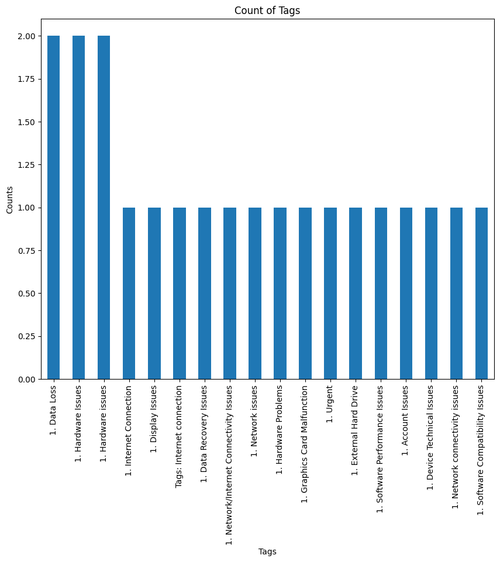

```python
fig, ax = plt.subplots()  # Create a figure and an axes.
test_data["Tags"].value_counts().plot(kind='bar', ax=ax, figsize = (10,8))  # Plotting the bar chart directly from the series

ax.set_xlabel('Tags')  # Set the x-axis label
ax.set_ylabel('Counts')  # Set the y-axis label
ax.set_title('Count of Tags')  # Title of the plot

plt.xticks(rotation=90)  # Rotate the x-axis labels to make them more readable

plt.show()  # Display the plot
```

```python
final_data["ETA"]
```

[output not shown]

**dtype:** object

```python
final_data["ETA"]=final_data["ETA"].apply(lambda x: x.split(".")[0])
```

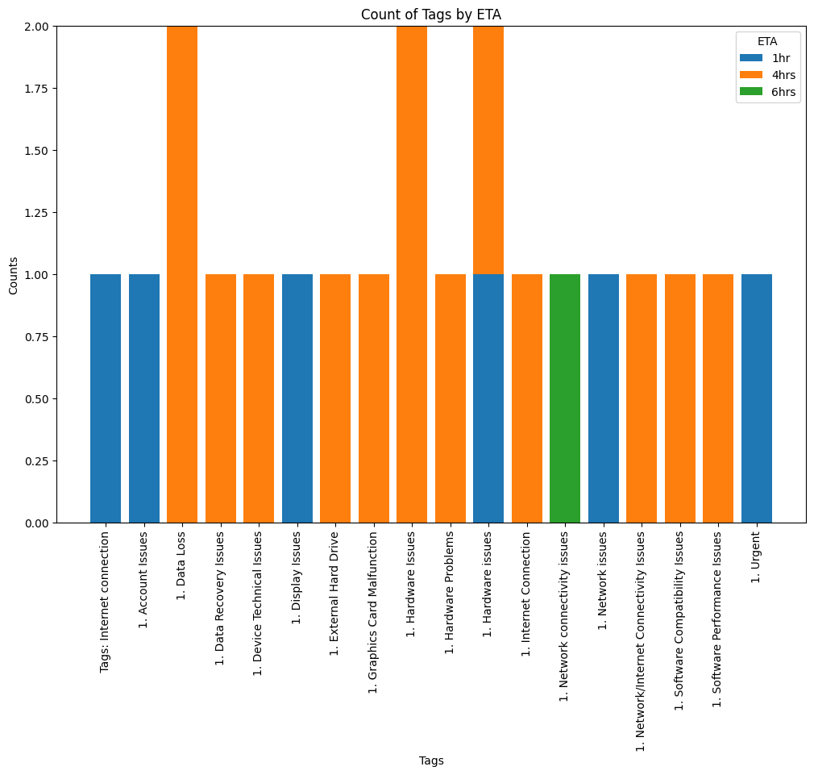

```python
# First, create a summary table (pivot) of counts for each tag and ETA
tag_counts = final_data.groupby(['Tags', 'ETA']).size().unstack(fill_value=0)

# Plotting
fig, ax = plt.subplots(figsize=(12, 8))  # You can adjust the figure size as needed

# We will plot a set of bars for each 'ETA'
for i, eta in enumerate(tag_counts.columns):
    ax.bar(tag_counts.index, tag_counts[eta], bottom=tag_counts[tag_counts.columns[:i]].sum(axis=1), label=str(eta))

ax.set_xlabel('Tags')  # Set the x-axis label
ax.set_ylabel('Counts')    # Set the y-axis label
ax.set_title('Count of Tags by ETA')  # Title of the plot
plt.xticks(rotation=90)  # Rotate the x-axis labels for better visibility
ax.legend(title='ETA')  # Adding legend with a title

plt.show()
```

```python
final_data["Category"]=final_data["Category"].apply(lambda x: x.split(":")[1])
```

```python
final_data["Category"]=final_data["Category"].apply(lambda x: x.split("(")[0])
```

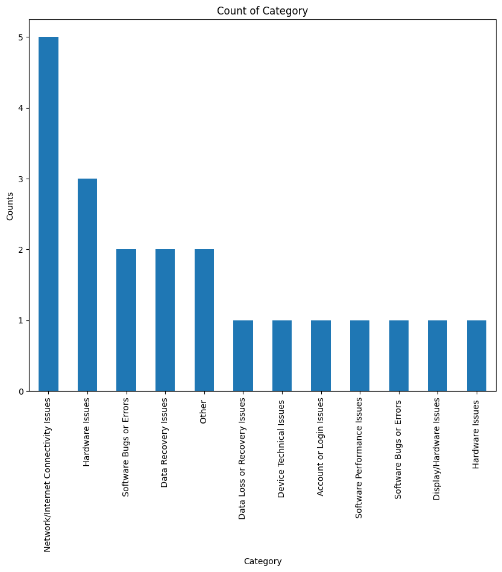

```python
fig, ax = plt.subplots()  # Create a figure and an axes.
final_data["Category"].value_counts().plot(kind='bar', ax=ax, figsize = (10,8))  # Plotting the bar chart directly from the series

ax.set_xlabel('Category')  # Set the x-axis label
ax.set_ylabel('Counts')  # Set the y-axis label
ax.set_title('Count of Category')  # Title of the plot

plt.xticks(rotation=90)  # Rotate the x-axis labels to make them more readable

plt.show()  # Display the plot
```

```python
final_data_4[["support_tick_id", "support_ticket_text", "Category", "Tags", "Priority", "ETA", "Response"]]
```

[output not shown]

**Key Accomplishments **

**Accomplishments:**

**Automated Categorization and Prioritization-** I leveraged state-of-the-art AI to categorize support tickets based on their content and assigned priority levels, ensuring that urgent issues are addressed promptly and efficiently.

**Enhanced Data Management-** All ticket information, including categories, priorities, and estimated resolution times, is systematically organized into a structured DataFrame, allowing for easy access and analysis.

## **Actionable Insights and Recommendations**

**Insights from the Notebook:**

**Prompt Engineering-** The success in generating relevant responses is significantly dependent on how well the prompts are engineered. Crafting prompts that explicitly guide the AI on what information to include (such as issue specifics, urgency, and customer reassurance) is crucial.

**Model Temperature Settings-** Adjusting the temperature parameter has been key in balancing creativity and relevance of the AI responses. A lower temperature generally results in more predictable and safer responses, while a higher temperature allows for more varied and creative outputs, which may be necessary depending on the complexity and variability of the support tickets.

**Categorization and Prioritization-** The process of defining and using categories, tags, and priorities effectively helps in not only organizing the support tickets but also in tailoring the responses appropriately. This categorization directly impacts how the model prioritizes and handles different types of inquiries.

**Use of Lambda Functions-** Employing Lambda functions for data cleaning or transformation demonstrates the flexibility and utility of using on-the-fly functions to adjust data inputs and outputs within the data processing pipeline. This method is beneficial for tasks that require quick and straightforward data manipulations without the need for extensive coding.

**Insights from Visualizations:**

**Distribution of Tags and Categories-** Frequent tags like "Data Loss" and categories such as "Network/Internet Connectivity Issues" indicate common problem areas that may require more focused customer support and product improvements.

**Prioritization and ETA Analysis-** The visualization of tags by ETA highlights the operational emphasis placed on different types of issues, with urgent problems like "Account Issues" being prioritized with shorter ETAs.

**Resource Allocation-** Analyzing the distribution of issues and their assigned priorities can help in better allocating support resources to ensure that urgent and high-impact issues are resolved quickly, improving overall customer satisfaction.

**Recommendations for Future Enhancements:**

**Continuous Prompt Refinement and Dynamic Temperature Adjustment-** Regularly update prompts and dynamically adjust temperature settings based on feedback and performance metrics to maintain or improve response quality.

**Advanced Categorization Techniques and Automated Quality Checks-** Utilize sophisticated NLP techniques for categorizing tickets and implement automated quality assurance checks to maintain high standards in response accuracy and relevance.

**Feedback Loop Integration and AI Model Training-** Establish robust feedback mechanisms to gather real-time user responses which can be used to further train and refine the AI model, ensuring it remains effective in addressing customer needs.

**Focus on High-Impact Issues and SLA Adjustments-** Increase resources for frequent issues and adjust service level agreements to ensure quick and effective resolutions, particularly for urgent categories.

Power Ahead